# Models of the Atom — Teacher Guide

## Cover

**Unit: Modern Physics — Lesson 02: Models of the Atom** East Meadow Schools × Valley Stream Central High School District Strategy chips: ACTIVE LEARNING

## Curated Resources (from East Meadow Scope & Sequence)

### NYSSLS Standards

This is a model-building lesson anchored to the Science and Engineering Practice **Developing and Using Models**. Students see that a scientific model is revised when new evidence appears — the central habit of mind behind every Modern Physics standard. It builds the atomic structure that the spectra lesson (HS-ESS1-2 connection) and the nuclear-change lesson (HS-PS1-8) depend on.

### Phenomenon

- Rutherford’s gold-foil scattering: most alpha particles pass straight through a thin gold foil, but a tiny fraction bounce sharply backward: https://www.youtube.com/watch?v=XBqHkraf8iE
- Rutherford’s own line: “as if you fired a 15-inch shell at a piece of tissue paper and it came back and hit you.”

### Javalab / Labs

- Rutherford scattering (interactive): https://javalab.org/en/rutherford_scattering_en/

### Assessments

- Exit ticket below (match a model to the evidence that overturned it). The gold-foil claim-evidence card sort in Phase 2 is the formative check.

## Lesson Overview

| **Duration** | 42 minutes (1 period) |
| --- | --- |
| **NYSSLS link** | SEP: Developing and Using Models (supports HS-PS1-8 and HS-ESS1-2 later in the unit) |
| **CCC focus** | Patterns / Stability and Change — a model holds until new evidence forces a change. |
| **Strategy chips** | ACTIVE LEARNING (claim–evidence card sort + model-revision gallery) |
| **Materials** | Pre-cut model/evidence card sets (one per group); chart paper or whiteboards; markers; the model-progression handout. |
| **Safety** | None — simulation and paper-based. |
| **Prior knowledge** | Atoms contain protons, neutrons, electrons (from earlier science); charge basics (+/−). |

**Lesson objectives — students can:**

- Sequence the atomic models (Dalton → Thomson → Rutherford → Bohr → quantum) and state what each got right.
- Explain how the gold-foil experiment provided evidence for a small, dense **nucleus**.
- Argue, using evidence, why a scientific model changes over time.

## Phase 1 · Engage *(0 – 10 min)*

### 0–2 min · Opening Connection (SEL)

Whip-around (one sentence, pass allowed): *“Tell me about a time you changed your mind because you got new information.”* Park responses — you’ll connect them to “scientists change models with new evidence.”

### 2–7 min · Phenomenon hook — the gold-foil surprise

**Teacher actions.** Play the gold-foil clip (or run the Javalab sim). Set up the expectation first: scientists thought the atom was a soft “pudding” of positive charge. Show alphas firing at the foil; most pass through, a rare few rebound.

**Sample teacher language:**

> “They expected every bullet to sail straight through soft pudding. Instead, one in thousands bounced *straight back*. Rutherford said it was like firing a cannon shell at tissue paper and having it come back at you. What inside the atom could do that?”

**Anticipated student responses:**

- “There’s something hard in the middle.” — gold; capture *small + hard + central*.
- “The whole atom is solid.” — counter with: “Then why do most pass straight through?”
- “It’s charged and pushed them back.” — capture; the dense center is positive.

### 7–10 min · Notice & Wonder + Turn-and-Talk #1

> “Turn and talk: if MOST pass through but a FEW bounce hard, what must the inside of the atom look like — solid, empty, or something in between?”

Target seed: mostly empty space with a tiny, dense, charged center.

### Bridge to Phase 2

Each student writes a one-sentence **initial model**: “The atom’s inside must be ______ because ______.”

## Phase 2 · Explore *(10 – 30 min)*

### 10–14 min · Initial Model (silent / individual)

Prompt:

> *“Draw what you think the inside of a gold atom looks like, based on the scattering result. Mark where the ‘hard’ part is and how much is empty.”*

### 14–30 min · Investigation — model/evidence card sort (ACTIVE LEARNING)

Groups of 3–4 receive shuffled cards: five **model cards** (Dalton solid sphere, Thomson plum pudding, Rutherford nucleus, Bohr orbits, quantum cloud) and matching **evidence cards** (e.g., “elements combine in fixed ratios,” “rays bend toward + plate → negative particles exist,” “alpha particles bounce back,” “atoms emit only specific colors of light,” “electrons behave as probability clouds”). Groups:

1. Order the models oldest → newest.
2. Match each model to the evidence that *supported* it and the evidence that *broke* it.
3. Build a chart-paper timeline; star the gold-foil card as the turning point for the nucleus.

**Teacher facilitation language:**

> “Which evidence card could Dalton’s solid sphere NOT explain?” “What did Thomson get right that Dalton missed — and what did the gold foil reveal that Thomson missed?” “Bohr’s orbits explain *which* observation that Rutherford’s couldn’t? (Hold that — it’s Lesson 03.)”

Use the progression figure to anchor the gallery:

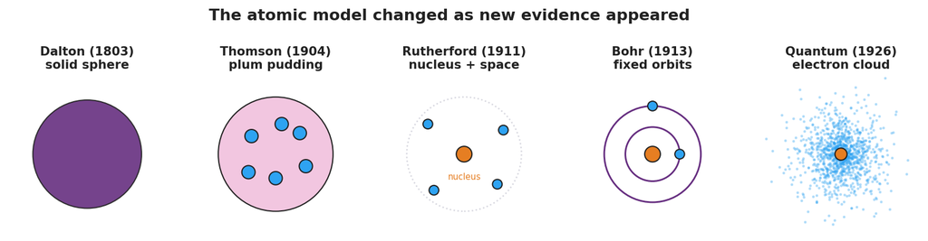

Five-panel progression of atomic models: Dalton solid sphere, Thomson plum pudding, Rutherford nucleus with empty space, Bohr fixed orbits, and the quantum electron cloud.

And the scattering diagram for the turning-point card:

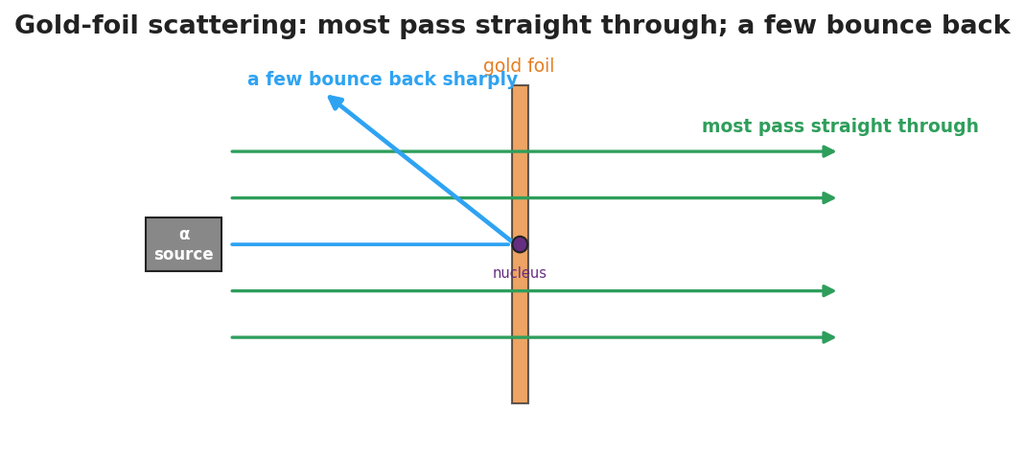

Gold-foil scattering: most alpha particles pass straight through the foil while a few deflect sharply off the tiny dense nucleus.

### Teacher facilitation during Explore

- **What to look for** — groups tying each *change* to a specific *new observation*, not just memorizing an order.
- **What to resist** — don’t pre-label which evidence breaks which model; let the sort do the reasoning.
- **What to redirect** — “the newest model is the only right one” → every model was the best fit for *its* evidence.

## Phase 3 · Explain *(30 – 36 min)*

### 30–33 min · Gallery walk + class consensus

Groups post timelines; one quick gallery walk. Then build consensus:

> “Across all five, what always triggered a new model? New, surprising *evidence* that the old model couldn’t explain.”

### 33–36 min · Vocabulary introduction (≤ 3 terms)

**Sample teacher language:**

> “The tiny, dense, positively charged center the gold foil revealed is the **nucleus**. The light, negatively charged particles around it are **electrons**. A picture scientists use to represent the atom’s structure is an **atomic model** — and that model has changed every time new evidence arrived.”

### Discussion prompts to deploy here

- “Why didn’t Thomson’s plum-pudding model survive the gold-foil result?”
  - *Sample student response:* “Soft, spread-out positive charge couldn’t bounce an alpha straight back; only a tiny dense nucleus could.”
- “Is the quantum model ‘the truth’ or just the current best model?”
  - *Sample student response:* “The current best model — it fits today’s evidence, and it could be revised again.”

## Phase 4 · Elaborate *(36 – 39 min)*

### 36–38 min · Revise the model

> *“Return to your Initial Model. Redraw the gold atom using the words nucleus and electron, showing the right proportions (tiny dense center, lots of empty space).”*

### 38–39 min · Return to the phenomenon

> “In one sentence, explain the gold-foil result using *nucleus*.”

Target: “Most alphas pass through the empty space, but the few that hit the tiny dense **nucleus** are pushed sharply back.”

## Phase 5 · Evaluate *(39 – 42 min)*

### 39–42 min · Exit Ticket + Closing Reflection

> *“(a) Which atomic model first included a tiny, dense nucleus, and what experiment supported it? (b) Name one thing the Thomson (plum-pudding) model got right. (c) Why do scientists change a model like the atom over time?”*

Expected: (a) Rutherford’s model; the gold-foil scattering experiment; (b) atoms contain negative electrons (and a positive part); (c) new evidence appears that the old model cannot explain. See `Answer_Key.docx`.

**Closing Reflection (SEL, 30 seconds):**

> “Whose idea in your group helped you make sense of the timeline today?”

## Common Misconceptions

- **Misconception:** “The newest model proves the old ones were wrong/stupid.” → **Correction:** Each model was the best explanation for the evidence available; models improve, they don’t shame their predecessors.
- **Misconception:** “The atom is mostly solid matter.” → **Correction:** An atom is overwhelmingly empty space; the nucleus is tiny but holds nearly all the mass.
- **Misconception:** “Electrons orbit the nucleus on neat circular tracks.” → **Correction:** That’s the Bohr picture; the current quantum model describes electrons as probability clouds, not fixed paths.

## Access & Differentiation

- **ELL/ENL supports:** Sentence frame: *“The ___ model changed to the ___ model because of evidence from ___.”* Word box: {Thomson, Rutherford, gold foil, nucleus, electron}. Provide the model cards with both a picture and a one-word label.
- **IEP/SPED supports:** Pre-sort the card set into the correct order for some groups; their task becomes matching evidence to a given sequence. Provide a fill-in timeline rather than blank chart paper.
- **Extensions:** Have students research and add a sixth card — a modern refinement (e.g., isotopes, the discovery of the neutron) — and justify where it fits and what evidence supports it.

## Strategy Spotlight

**ACTIVE LEARNING.** The card sort makes students *do* the historical reasoning rather than receive a timeline. Cognitive load stays on the model–evidence relationship. Keep groups to 3–4, rotate a “challenger” role whose job is to ask “what evidence breaks this model?”, and end with a brief gallery walk so every group sees an alternative arrangement before consensus. This positions the gold-foil result as the turning point students *argue toward*, not one you announce.

## NYSSLS Observation Checklist Crosswalk

| # | Checklist item | Where it appears in this lesson |
| --- | --- | --- |
| 1 | Local/relatable phenomenon | Phase 1 — gold-foil “cannon shell off tissue paper” |
| 2 | Turn and Talk (2–3×) | Phase 1 (TT#1 — what’s inside the atom), Phase 3 (gallery-walk consensus discussion) |
| 3 | Students develop questions/models/procedures | Phase 1 (initial model), Phase 2 (card sort + timeline), Phase 4 (revise model) |
| 4 | CCC defined and used | Lesson Overview · *Patterns / Stability and Change*, restated in Phase 3 |
| 5 | ENL — ≤ 3 vocab, second half | Phase 3 — vocabulary at 33–36 min (nucleus / electron / atomic model) |
| 6 | Revisit phenomenon with evidence | Phase 4 — re-explain gold foil using *nucleus* |
| 7 | ENL/SPED supports | Access & Differentiation block |
| 8 | Assessment check | Phase 5 — Exit Ticket (model ↔︎ evidence) |

## Companion Materials

- `Student_Worksheet.docx` — the 5E student investigation with the card-sort timeline (hand out at start of Phase 2)
- `Student_Notes.docx` — guided note-guide for the model progression and vocabulary
- `Answer_Key.docx` — answers to “Make It Make Sense” prompts and the Exit Ticket

## Key Vocabulary (max 3)

- **nucleus** — the tiny, dense, positively charged center of an atom; it holds nearly all the atom’s mass
- **electron** — a light, negatively charged particle found in the space around the nucleus
- **atomic model** — a scientific picture or representation of the atom’s structure, revised as new evidence appears